# Regional association plots of eQTLs

Silva Kasela

8/3/2020

### Regional association plots of eQTLs for ACE2 and TMPRSS2

gene_id

gene_name

gene_chr

gene_start

gene_end

strand

gene_type

num_var

beta_shape1

beta_shape2

true_df

pval_true_df

variant_id

tss_distance

chr

variant_pos

ref

alt

rs_id_dbSNP151_GRCh38p7

maf

ma_samples

ma_count

ref_factor

pval_nominal

slope

slope_se

pval_perm

pval_beta

qval

pval_nominal_threshold

ENSG00000184012

TMPRSS2

chr21

41464305

41531116

protein_coding

6690

1.04399

1022.990

107.3340

0.0000967

chr21_40854223_G_A_b38

-676893

chr21

40854223

G

A

rs73903038

0.0625000

16

18

1

0.0000321

-0.706855

0.163667

0.080292

0.0833523

0.143124

0.0000237

ENSG00000130234

ACE2

chrX

15561033

15602148

protein_coding

2511

1.04191

143.485

99.4348

0.0042943

chrX_16363381_C_T_b38

761233

chrX

16363381

C

T

rs56154349

0.0804196

17

23

1

0.0015528

0.363595

0.112305

0.448255

0.4404750

0.365670

0.0001673

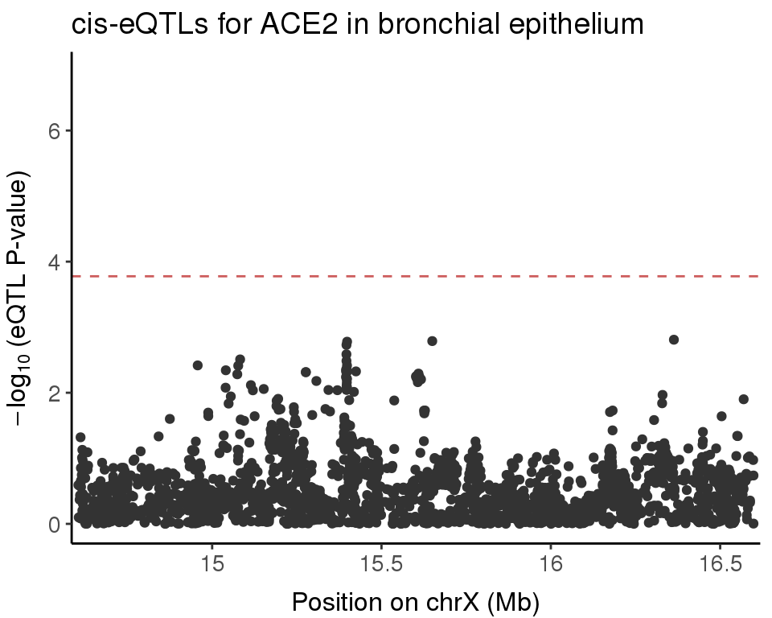

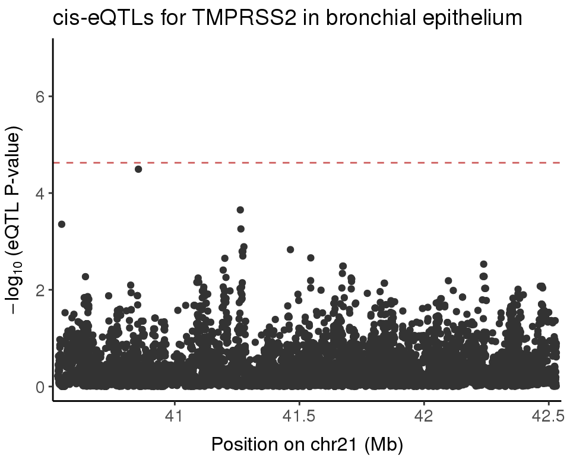

- Gene track

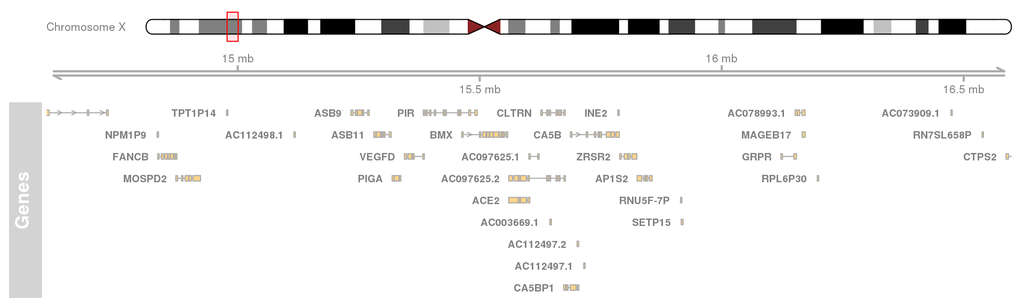

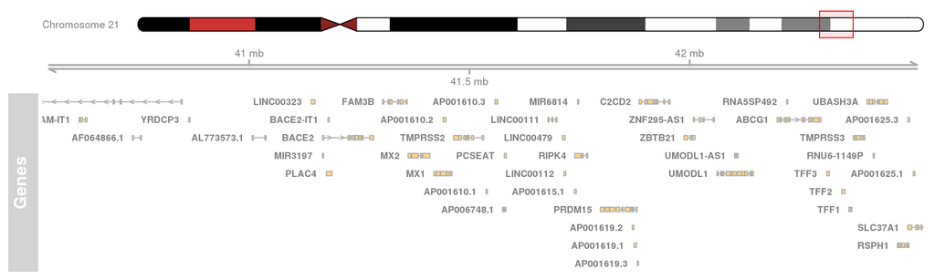

### Regional association plots of eQTLs in the chr3 locus associated with COVID-19 GWAS

At locus 3p21.31, the association signal related to COVID-19 spanned the genes SLC6A20, LZTFL1, CCR9, FYCO1, CXCR6, and XCR1

- COVID-19 GWAS data: ANA_C2_V2 - covid vs. population (round 3)
  - Lead variant: chr3_45867022_C_G_b38
- COVID-19 GWAS data: ANA_B2_V2 - hospitalized covid vs. population (round 3)
  - Lead variant: chr3_45867532_A_G_b38
- Ellinghaus et al. 2020, severe COVID-19 with respiratory failure
  - Lead variant: chr3_45834967_G_GA_b38

gene_id

gene_name

gene_chr

gene_start

gene_end

strand

gene_type

num_var

beta_shape1

beta_shape2

true_df

pval_true_df

variant_id

tss_distance

chr

variant_pos

ref

alt

rs_id_dbSNP151_GRCh38p7

maf

ma_samples

ma_count

ref_factor

pval_nominal

slope

slope_se

pval_perm

pval_beta

qval

pval_nominal_threshold

ENSG00000163817

SLC6A20

chr3

45755449

45796536

protein_coding

5197

1.06988

294.487

99.9709

0.0034571

chr3_45796521_G_T_b38

-15

chr3

45796521

G

T

rs2271616

0.0902778

25

26

1

0.0012317

0.444571

0.1343580

0.617638

0.609597

0.427322

9.11e-05

ENSG00000163818

LZTFL1

chr3

45823316

45916042

protein_coding

5188

1.04062

273.102

99.2479

0.0013368

chr3_46655307_T_C_b38

739265

chr3

46655307

T

C

rs17079097

0.1458330

35

42

1

0.0003732

-0.138956

0.0379605

0.288571

0.287564

0.293681

8.74e-05

ENSG00000172215

CXCR6

chr3

45940933

45948351

protein_coding

5184

1.04339

291.378

100.6200

0.0018394

chr3_46458968_C_T_b38

518035

chr3

46458968

C

T

rs4547741

0.0590278

16

17

1

0.0006002

-0.578636

0.1642220

0.398860

0.394241

0.346788

8.29e-05

ENSG00000163820

FYCO1

chr3

45917899

45995824

protein_coding

5189

1.05557

299.060

101.0060

0.0023944

chr3_45454830_T_C_b38

-540994

chr3

45454830

T

C

rs9858131

0.0902778

23

26

1

0.0008424

-0.581663

0.1699050

0.492651

0.485363

0.383710

8.48e-05

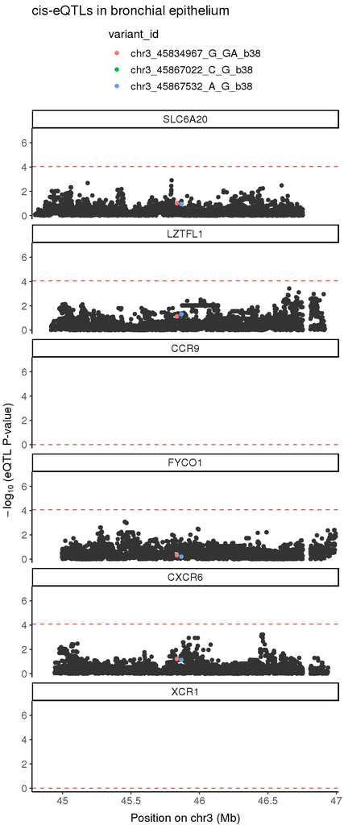

- Gene track

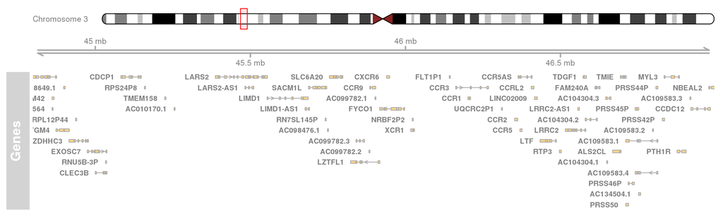